# Homework_1

Isaac Rosenthal

September 8, 2016

#### 0.)

This was written in R markdown, I like free points!

#### 1.)

*Create a vector of 100 randomly distributed numbers between 0 and 100 using* `runif` *and save the vector into the variable* `my_vec`. *If you cannot figure out* `runif`*, try* `?runif`. *What information does* `str` *and* `summary` *tell you about* `my_vec`*? How do they differ?*

First, make the vector.

```r
myvec <- runif(100, min = 0, max = 100) #this creates a vector of 100 values with a minimum value of 0 and a maximum value of 100
myvec
```

```
##   [1] 14.2203728 68.7137669 95.5672971 65.1266552 25.8641058 95.9444980
##   [7] 29.7439763 43.6919354 50.7845050 15.4711460  5.5400610 39.2407185
##  [13] 59.6661239 83.2788854 81.5852886 10.2440600 78.9100983 10.4433745
##  [19] 66.2604448 21.2171840 46.7219666 44.9898327  6.7309522 81.7646536
##  [25] 91.5497283 38.2887342 43.1073356 19.9984507  4.1865765 87.4500371
##  [31] 49.7884783 90.7969110 61.6411004  5.5833314 47.6027860 21.0638220
##  [37] 32.8116456 98.7505741 75.2918961 64.0367764 89.3444947 24.7572856
##  [43] 35.1073223 49.2800798 43.0043741 16.1548774  0.9974100 31.1077122
##  [49] 71.3810511 27.5428705 79.2975769 52.9312777 52.8743155 14.6629659
##  [55] 35.5876455 34.0729789 11.7523671 43.1228491 66.0058467 75.1213621
##  [61] 60.4604988 97.1424498 21.9383142  0.4172324 37.5525835 29.3794464
##  [67]  4.7628725 28.1891276 89.0078654  5.3932246 29.8296027 21.6416145
##  [73] 89.2563437 17.0556829 40.1533317 59.6292787 22.8756264 37.1117388
##  [79] 63.0577310 89.5680929 69.9982046 72.7059484 45.9893301 48.4005055
##  [85] 86.3730889  1.8512939 34.0103334  6.8877974 75.4109413 97.4654851
##  [91] 34.7692088 63.1808798 61.3113978 44.0404405 80.5691125 93.7556810
##  [97] 11.2532404 67.7444416 50.0029590  9.8362716
```

Then, run `str` and `summary` on it to find out more.

```r
str(myvec) #to see the structure of myvec
```

```
##  num [1:100] 14.2 68.7 95.6 65.1 25.9 ...
```

```r
summary(myvec) #to see some summary statistics of myvec
```

```
##    Min. 1st Qu.  Median    Mean 3rd Qu.    Max.
##  0.4172 22.6413 44.5151 47.2776 70.3439 98.7506
```

`str` tells me that it is numeric and contains 100 values.

`summary` tells me the minimum, 1st quartile, median, mean, 3rd quartile, and maximum values of `myvec`.

They are different because they tell me different things. str tells me about the structure of the vector itself, whereas summary tells me more about the values within the vector.

#### 2.)

*Try out a little plot. What does* `hist(my_vec)` *show you? What information does the helpfile for* `hist` *tell you about what you just did?*

First, run `hist`.

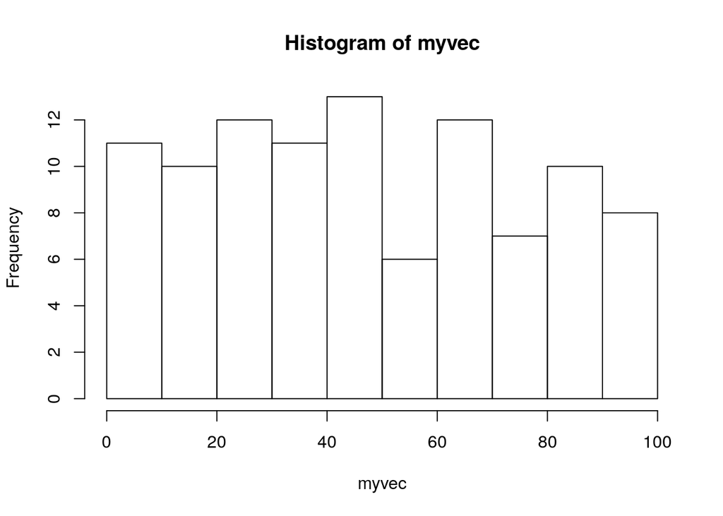

```r
hist(myvec) #creates a histogram from the data in myvec
```

`hist` shows me a histogram from the values within `myvec`  
The helpfile for `hist` tells me a lot. It explains that it creates a histogram of the given data. It also provides a lot of info about the many arguments that can be used to modify the plot, primarily some additional labelng and aesthetic choices. It also gives some examples and references to if you want to know more.

[figure not shown]

#### 3.)

*Load up the mtcars data set using* `data(mtcars)`*. Apply the following functions to* `mtcars`*:* `class` *,* `str` *,* `summary`*. What do these three functions tell you about* `mtcars`*?*

First, I will load the data.

```r
data(mtcars) # load the data
```

Now I will look at the class of `mtcars`

```r
class(mtcars)
```

```
## [1] "data.frame"
```

`class` tells me that `mtcars` has the class of data.frame.

Then I will look at the structure of `mtcars`

```r
str(mtcars)
```

```
## 'data.frame':    32 obs. of  11 variables:
##  $ mpg : num  21 21 22.8 21.4 18.7 18.1 14.3 24.4 22.8 19.2 ...
##  $ cyl : num  6 6 4 6 8 6 8 4 4 6 ...
##  $ disp: num  160 160 108 258 360 ...
##  $ hp  : num  110 110 93 110 175 105 245 62 95 123 ...
##  $ drat: num  3.9 3.9 3.85 3.08 3.15 2.76 3.21 3.69 3.92 3.92 ...
##  $ wt  : num  2.62 2.88 2.32 3.21 3.44 ...
##  $ qsec: num  16.5 17 18.6 19.4 17 ...
##  $ vs  : num  0 0 1 1 0 1 0 1 1 1 ...
##  $ am  : num  1 1 1 0 0 0 0 0 0 0 ...
##  $ gear: num  4 4 4 3 3 3 3 4 4 4 ...
##  $ carb: num  4 4 1 1 2 1 4 2 2 4 ...
```

`str` tells me that `mtcars` is a data frame with 32 observations of 11 variables. All variables in this case are numeric and include things like mpg (miles per gallon), cyl (number of cylinders), disp (displacement), and various other statistics about the cars.

Finally, I will check out some summary statistics of `mtcars`

```r
summary(mtcars)
```

```
##       mpg             cyl             disp             hp
##  Min.   :10.40   Min.   :4.000   Min.   : 71.1   Min.   : 52.0
##  1st Qu.:15.43   1st Qu.:4.000   1st Qu.:120.8   1st Qu.: 96.5
##  Median :19.20   Median :6.000   Median :196.3   Median :123.0
##  Mean   :20.09   Mean   :6.188   Mean   :230.7   Mean   :146.7
##  3rd Qu.:22.80   3rd Qu.:8.000   3rd Qu.:326.0   3rd Qu.:180.0
##  Max.   :33.90   Max.   :8.000   Max.   :472.0   Max.   :335.0
##       drat             wt             qsec             vs
##  Min.   :2.760   Min.   :1.513   Min.   :14.50   Min.   :0.0000
##  1st Qu.:3.080   1st Qu.:2.581   1st Qu.:16.89   1st Qu.:0.0000
##  Median :3.695   Median :3.325   Median :17.71   Median :0.0000
##  Mean   :3.597   Mean   :3.217   Mean   :17.85   Mean   :0.4375
##  3rd Qu.:3.920   3rd Qu.:3.610   3rd Qu.:18.90   3rd Qu.:1.0000
##  Max.   :4.930   Max.   :5.424   Max.   :22.90   Max.   :1.0000
##        am              gear            carb
##  Min.   :0.0000   Min.   :3.000   Min.   :1.000
##  1st Qu.:0.0000   1st Qu.:3.000   1st Qu.:2.000
##  Median :0.0000   Median :4.000   Median :2.000
##  Mean   :0.4062   Mean   :3.688   Mean   :2.812
##  3rd Qu.:1.0000   3rd Qu.:4.000   3rd Qu.:4.000
##  Max.   :1.0000   Max.   :5.000   Max.   :8.000
```

`summary` tells me the minimum, 1st quartile, median, mean, 3rd quartile, and maximum values of each column (which correspond to variables) of the data frame.

#### 4.)

*Look at the help file for the class* `data.frame`*. What does it tell you about these objects?*

The help file tells me that a data frame is a “tightly coupled collection of variables”, and that it is very similar to both matrices and lists. More specifically, it is a list of variables, each with a unique row name and of the same length. The help file also mentions that they are the fundamental data structure used by R.

#### 5.)

For my final project, I am going to polish up my progress on Floating Forests, wherever that may be. I’m hoping to be able to include some maps, potentially creating a few figures that are at least poster quality. I would love to be able to perform some analyses on kelp coverage changes over time, at least within CA.

My backup idea (if FF is not at a point where I can test hypotheses easily) is to use some of the KEEN data.